# MOOC Dataset

# Gradient Boosting

Now let’s fit the Gradient Boosting model. It also consists of an ensemble method, but seeks to reduce errors in the training base at each step of the algorithm.

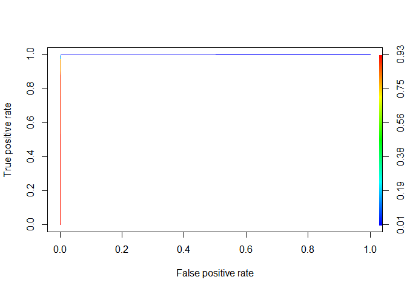

```r
# Fit the model
model<-gbm(data=dados_filtrados[train==1],as.character(certified)~.,distribution = "bernoulli",n.trees = 10,
interaction.depth = 2,cv.folds = 2)

# Predictions
gbm.model.prediction<-predict(model,newdata = dados_filtrados[train==1,-c('certified')],n.trees = 10,type = 'response')

pred <- prediction(gbm.model.prediction,dados_filtrados[train==1,certified])
perf <- performance(pred,"tpr","fpr")
plot(perf,colorize=TRUE)
```

```r
dados_test$predito_gbm_prob<-predict(model,newdata = dados_test[,-c('certified')],n.trees = 10,type = 'response')

dados_test$predito_gbm<-ifelse(dados_test$predito_gbm_prob>=0.5,1,0)


matriz_confusao<-table(dados_test$predito_gbm,dados_test$certified)
precisao_gbm<-sum(diag(matriz_confusao))/sum(matriz_confusao)
```

The accuracy for this model turns out to be 99.8333%.

#XGboost Model

We will now adjust a more advanced model than Gradient Boosting, XGboost. To adjust this model, the test and training matrices need to go through some pre-processing.

```r
# Pre-processing matrices
train_mat<-sparse.model.matrix(data = dados_filtrados[train==1,],certified~.-1)

test_mat<-sparse.model.matrix(data = dados_filtrados[train==0,],certified~.-1)

train_label<-as.numeric(dados_filtrados[train==1,]$certified)-1
test_label<-as.numeric(dados_filtrados[train==0]$certified)-1

# We need to convert data to DMatrix form
train_dMatrix<-xgb.DMatrix(data = as.matrix(train_mat),label=train_label)
test_dMatrix<-xgb.DMatrix(data = as.matrix(test_mat),label=test_label)

## Modeling
params <- list("objective" = "reg:logistic",
               "eval_metric" = "auc")
watchlist <- list(train = train_dMatrix, test = test_dMatrix)

# eXtreme Gradient Boosting Model
xgb_model <- xgb.train(params = params,
                       data = train_dMatrix,
                       nrounds = 2000,
                       watchlist = watchlist,
                       eta = 0.02,
                       max.depth = 4,
                       gamma = 0,
                       subsample = 1,
                       colsample_bytree = 1,
                       missing = NA,
                       seed = 222,verbose=0)

# Prediction

dados_test$predito_xgb_prob<-predict(xgb_model,newdata = test_dMatrix)

dados_test$predito_xgb<-ifelse(dados_test$predito_xgb_prob>=0.5,1,0)


matriz_confusao<-table(dados_test$predito_xgb,dados_test$certified)
sum(diag(matriz_confusao))/sum(matriz_confusao)
```

```
## [1] 0.9995721
```

```r
precisao_xgb<-sum(diag(matriz_confusao))/sum(matriz_confusao)
```

The accuracy for this model turns out to be 99.9572%.

# Deep Learning

Finally, we will use a deep neural network. This model will be adjusted using the Keras package.

```r
# Pre-processing data
final.training <- dados_filtrados[train==1,]
final.test <- dados_filtrados[train==0,]


X_train <- final.training %>%
  select(-c(certified,YoB,gender,LoE_DI,final_cc_cname_DI)) %>%
  scale()

y_train <- to_categorical(final.training$certified)



X_test <- final.test %>%
  select(-c(certified,YoB,gender,LoE_DI,final_cc_cname_DI)) %>%
  scale()

y_test <- to_categorical(final.test$certified)


model <- keras_model_sequential()

model %>%
  layer_dense(units = 256, activation = 'relu', input_shape = ncol(X_train)) %>%
  layer_dropout(rate = 0.4) %>%
  layer_dense(units = 128, activation = 'relu') %>%
  layer_dropout(rate = 0.3) %>%
  layer_dense(units = 2, activation = 'sigmoid')

history <- model %>% compile(
  loss = 'binary_crossentropy',
  optimizer = 'adam',
  metrics = c('accuracy')
)

model %>% fit(
  X_train, y_train,
  epochs = 10,
  batch_size = 5,
  validation_split = 0.3
)
summary(model)
```

```
## Model: "sequential"
## ________________________________________________________________________________
## Layer (type)                        Output Shape                    Param #
## ================================================================================
## dense (Dense)                       (None, 256)                     1792
## ________________________________________________________________________________
## dropout (Dropout)                   (None, 256)                     0
## ________________________________________________________________________________
## dense_1 (Dense)                     (None, 128)                     32896
## ________________________________________________________________________________
## dropout_1 (Dropout)                 (None, 128)                     0
## ________________________________________________________________________________
## dense_2 (Dense)                     (None, 2)                       258
## ================================================================================
## Total params: 34,946
## Trainable params: 34,946
## Non-trainable params: 0
## ________________________________________________________________________________
```

```r
resultados_keras<-model %>% evaluate(X_test, y_test)
```

The accuracy for this model turns out to be 99.2127%.

# Best model and app deployment

The model that presented the best results was the XGboost. It was then used to make predictions and create the App available at https://naiufop.shinyapps.io/App_Mooc/